# MPDW PRAKTIKUM 2 Bagian Sales dan Advert

Daffa Lukman Wahid Al Jailani

2026-05-25

# SOAL 1

## PREPARASI DATA

```r
library(readxl)
salesdata <- read_excel("C:\\Users\\Lenovo\\Downloads\\Data MPDW Prak.xlsx", sheet = "Sheet2")
colnames(salesdata) <- c("Y", paste0("X", 1))
data.frame(salesdata)
```

```
##       Y   X1
## 1  11.7  9.4
## 2  12.0  9.6
## 3  12.3 10.0
## 4  12.8 10.4
## 5  13.1 10.8
## 6  13.6 10.9
## 7  13.9 11.7
## 8  14.4 12.2
## 9  14.7 12.5
## 10 15.3 12.9
## 11 15.5 13.0
## 12 15.8 13.2
## 13 16.1 13.8
## 14 16.6 14.2
```

[output cut: 26 more lines]

## EKSPLORASI

```r
#install.packages(c("dplyr", "ggplot2", "psych", "GGally", "corrplot", "TTR", "forecast", "lmtest", "orcutt", "HoRM"))
library(dplyr)
library(ggplot2)
library(psych)
library(GGally)
library(corrplot)
library(TTR)
library(forecast)
library(lmtest)
library(orcutt) #untuk membuat model regresi Cochrane-Orcutt
library(HoRM) #untuk membuat model regresi Hildreth-Lu
# Struktur data
str(salesdata)
```

```
## tibble [40 × 2] (S3: tbl_df/tbl/data.frame)
##  $ Y : num [1:40] 11.7 12 12.3 12.8 13.1 13.6 13.9 14.4 14.7 15.3 ...
##  $ X1: num [1:40] 9.4 9.6 10 10.4 10.8 10.9 11.7 12.2 12.5 12.9 ...
```

```r
# Statistik Deskriptif
describe(salesdata)
```

```
##    vars  n  mean   sd median trimmed  mad  min  max range  skew kurtosis   se
## Y     1 40 17.13 2.59   17.9   17.35 2.52 11.7 21.0   9.3 -0.59    -0.84 0.41
## X1    2 40 15.72 3.57   15.9   15.76 4.23  9.4 22.1  12.7 -0.08    -1.10 0.56
```

## OLS

```r
model <- lm(
  Y ~ X1,
  data = salesdata
)

summary(model)
```

```
##
## Call:
## lm(formula = Y ~ X1, data = salesdata)
##
## Residuals:
##      Min       1Q   Median       3Q      Max
## -1.03758 -0.40343  0.08933  0.45674  0.74036
##
## Coefficients:
##             Estimate Std. Error t value Pr(>|t|)
## (Intercept)  5.96513    0.38092   15.66   <2e-16 ***
## X1           0.71035    0.02365   30.04   <2e-16 ***
## ---
## Signif. codes:  0 '***' 0.001 '**' 0.01 '*' 0.05 '.' 0.1 ' ' 1
##
## Residual standard error: 0.527 on 38 degrees of freedom
## Multiple R-squared:  0.9596, Adjusted R-squared:  0.9585
## F-statistic: 902.3 on 1 and 38 DF,  p-value: < 2.2e-16
```

Didapat model OLS:
$$Y = 5.965+0.710X_1$$
## DIAGNOSTIK

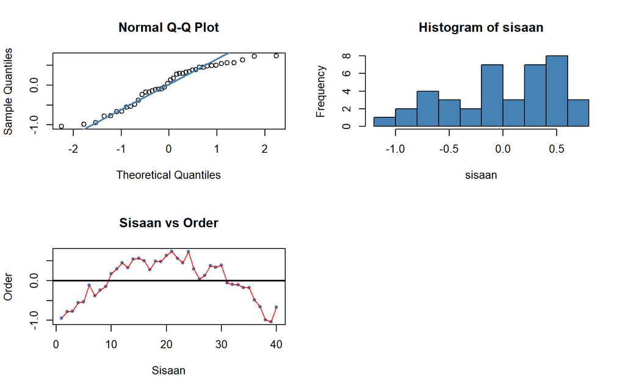

```r
#sisaan dan fitted value
sisaan<- residuals(model)
fitValue<- predict(model)

#Diagnostik dengan eksploratif
par(mfrow = c(2,2))
qqnorm(sisaan)
qqline(sisaan,
       col = "steelblue",
       lwd = 2)

hist(sisaan,
     col = "steelblue")
plot(seq_along(sisaan), sisaan,
     col = "steelblue",
     pch = 20,
     xlab = "Sisaan",
     ylab = "Order",
     main = "Sisaan vs Order")
lines(seq_along(sisaan),
      sisaan,
      col = "red")
abline(a = 0, b = 0, lwd = 2)
```

## NORMALITAS SISAAN

```r
#Melihat Sisaan Menyebar Normal/Tidak
#H0: sisaan mengikuti sebaran normal
#H1: sisaan tidak mengikuti sebaran normal
shapiro.test(sisaan)
```

```
##
##  Shapiro-Wilk normality test
##
## data:  sisaan
## W = 0.93205, p-value = 0.0188
```

```r
ks.test(sisaan, "pnorm", mean=mean(sisaan), sd=sd(sisaan))
```

```
##
##  Asymptotic one-sample Kolmogorov-Smirnov test
##
## data:  sisaan
## D = 0.15458, p-value = 0.2948
## alternative hypothesis: two-sided
```

Berdasarkan uji formal, terdapat perbedaan hasil antara kedua uji. Uji Shapiro-Wilk menghasilkan p-value = 0.0188 (< 0.05), sehingga H0 ditolak dan disimpulkan sisaan tidak menyebar normal. Namun, uji Kolmogorov-Smirnov menghasilkan p-value = 0.2948 (> 0.05), sehingga gagal tolak H0 dan sisaan dianggap menyebar normal. hasil Shapiro-Wilk yang lebih diutamakan, sehingga disimpulkan sisaan belum sepenuhnya menyebar normal.

## AUTOKORELASI

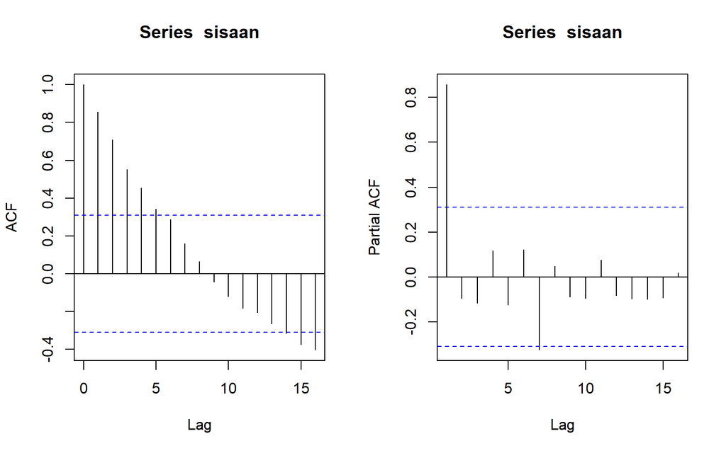

```r
par(mfrow = c(1,2))
acf(sisaan)
pacf(sisaan)
```

```r
#Deteksi autokorelasi dengan uji-Durbin Watson
#H0: tidak ada autokorelasi
#H1: ada autokorelasi
dwtest(model)
```

```
##
##  Durbin-Watson test
##
## data:  model
## DW = 0.16204, p-value < 2.2e-16
## alternative hypothesis: true autocorrelation is greater than 0
```

Berdasarkan hasil DW Test, didapatkan nilai $DW = 0.16204$ dan *p-value* $< 2.2\times10^{-16}$. Berdasarkan tabel Durbin-Watson untuk $n=40$ dan $k=1$ diperoleh nilai $D_L = 1.442$ dan $D_U = 1.544$. Nilai DW jauh berada di bawah nilai $D_L$, bahkan mendekati 0. Artinya, berada di daerah penolakan H0. Didukung dengan nilai *p-value* yang sangat kecil (jauh < 0.05), tolak H0, cukup bukti mengatakan adanya autokorelasi positif yang sangat kuat pada sisaan. Sehingga diperlukan penanganan autokorelasi. Penanganan yang akan digunakan menggunakan dua metode, yaitu Cochrane-Orcutt dan Hildreth-Lu.

## PENANGANAN AUTOKORELASI

### Cochrane-Orcutt

```r
#Penanganan Autokorelasi Cochrane-Orcutt
modelCO<-cochrane.orcutt(model)
modelCO
```

```
## Cochrane-orcutt estimation for first order autocorrelation
##
## Call:
## lm(formula = Y ~ X1, data = salesdata)
##
##  number of interaction: 39
##  rho 0.903123
##
## Durbin-Watson statistic
## (original):    0.16204 , p-value: 8.935e-20
## (transformed): 1.93925 , p-value: 3.78e-01
##
##  coefficients:
## (Intercept)          X1
##   10.252375    0.488489
```

```r
rho <- modelCO$rho
```

Hasil keluaran model setelah dilakukan penanganan adalah sebagai berikut.
$$Y = 10.252375 +
0.488489X_1$$
Hasil juga menunjukkan bahwa nilai DW dan p-value meningkat menjadi $1.93925$ dan $0.378$. Nilai DW sudah berada pada rentang DU < DW < 4-DU atau $1.544 < DW < 2.456$. Hal tersebut juga didukung dengan nilai *p-value* > 0.05, artinya belum cukup bukti menyatakan bahwa sisaan terdapat autokorelasi pada taraf nyata 5%. Untuk nilai $\hat{\rho}$ optimum yang digunakan adalah $0.903123$.

```r
salesdata$Y
```

```
##  [1] 11.7 12.0 12.3 12.8 13.1 13.6 13.9 14.4 14.7 15.3 15.5 15.8 16.1 16.6 16.9
## [16] 16.7 16.9 17.4 17.6 17.9 18.0 17.9 18.0 18.2 18.2 18.3 18.6 19.2 19.3 19.5
## [31] 19.2 19.3 19.5 20.0 20.0 19.9 19.8 19.9 20.2 21.0
```

```r
salesdata$X1
```

```
##  [1]  9.4  9.6 10.0 10.4 10.8 10.9 11.7 12.2 12.5 12.9 13.0 13.2 13.8 14.2 14.6
## [16] 14.4 15.0 15.4 15.7 15.9 15.9 16.0 16.3 16.2 16.8 17.3 17.6 18.1 18.3 18.5
## [31] 18.7 18.9 19.2 20.0 20.0 20.3 20.4 21.0 21.5 22.1
```

```r
salesdata$Y[-1]
```

```
##  [1] 12.0 12.3 12.8 13.1 13.6 13.9 14.4 14.7 15.3 15.5 15.8 16.1 16.6 16.9 16.7
## [16] 16.9 17.4 17.6 17.9 18.0 17.9 18.0 18.2 18.2 18.3 18.6 19.2 19.3 19.5 19.2
## [31] 19.3 19.5 20.0 20.0 19.9 19.8 19.9 20.2 21.0
```

```r
salesdata$X1[-1]
```

```
##  [1]  9.6 10.0 10.4 10.8 10.9 11.7 12.2 12.5 12.9 13.0 13.2 13.8 14.2 14.6 14.4
## [16] 15.0 15.4 15.7 15.9 15.9 16.0 16.3 16.2 16.8 17.3 17.6 18.1 18.3 18.5 18.7
## [31] 18.9 19.2 20.0 20.0 20.3 20.4 21.0 21.5 22.1
```

```r
#Transformasi Manual
Y.trans<- salesdata$Y[-1]-salesdata$Y[-20]*rho
X.trans<- salesdata$X1[-1]-salesdata$X1[-20]*rho
modelCOmanual<- lm(Y.trans~X.trans)
summary(modelCOmanual)
```

```
##
## Call:
## lm(formula = Y.trans ~ X.trans)
##
## Residuals:
##       Min        1Q    Median        3Q       Max
## -0.277329 -0.035373 -0.007666  0.024345  0.244037
##
## Coefficients:
##             Estimate Std. Error t value Pr(>|t|)
## (Intercept)  1.02518    0.12059   8.501 3.15e-10 ***
## X.trans      0.46858    0.07061   6.636 8.70e-08 ***
## ---
## Signif. codes:  0 '***' 0.001 '**' 0.01 '*' 0.05 '.' 0.1 ' ' 1
##
## Residual standard error: 0.1119 on 37 degrees of freedom
## Multiple R-squared:  0.5434, Adjusted R-squared:  0.5311
## F-statistic: 44.04 on 1 and 37 DF,  p-value: 8.697e-08
```

```r
#Mencari Penduga Koefisien Regresi setelah Transformasi ke Persamaan Awal
b0bintang <- modelCOmanual$coefficients[-2]
b0 <- b0bintang/(1-rho)
b1 <- modelCOmanual$coefficients[-1]
b0
```

```
## (Intercept)
##    10.58234
```

```r
b1
```

```
##   X.trans
## 0.4685834
```

### Hildret-Lu

```r
# ambil y dan x (satu prediktor saja)
y <- salesdata$Y
x <- salesdata$X1

# grid search rho 0–0.9
r <- seq(0, 0.9, by = 0.1)
tab <- data.frame(
  rho = r,
  SSE = sapply(r, function(rr) deviance(hildreth.lu(y, x, rr)))
)

tab            # tabel rho vs SSE
```

```
##    rho      SSE
## 1  0.0 9.561851
## 2  0.1 7.845710
## 3  0.2 6.330287
## 4  0.3 5.015381
## 5  0.4 3.900668
## 6  0.5 2.985599
## 7  0.6 2.269173
## 8  0.7 1.749430
## 9  0.8 1.422573
## 10 0.9 1.291395
```

```r
rho_hat <- tab$rho[which.min(tab$SSE)]   # rho terbaik
fit_hl  <- hildreth.lu(y, x, rho_hat)    # model final
summary(fit_hl)
```

```
##
## Call:
## lm(formula = y ~ x)
##
## Residuals:
##     Min      1Q  Median      3Q     Max
## -0.3749 -0.1461  0.0148  0.1057  0.4496
##
## Coefficients:
##             Estimate Std. Error t value Pr(>|t|)
## (Intercept)  1.01310    0.14198   7.135 1.87e-08 ***
## x            0.49358    0.07379   6.689 7.38e-08 ***
## ---
## Signif. codes:  0 '***' 0.001 '**' 0.01 '*' 0.05 '.' 0.1 ' ' 1
##
## Residual standard error: 0.1868 on 37 degrees of freedom
## Multiple R-squared:  0.5474, Adjusted R-squared:  0.5351
## F-statistic: 44.74 on 1 and 37 DF,  p-value: 7.382e-08
```

```r
#Penanganan Autokorelasi Hildreth lu
# Hildreth-Lu
hildreth.lu.func<- function(r, model){
  x <- model.matrix(model)[,-1]
  y <- model.response(model.frame(model))
  n <- length(y)
  t <- 2:n
  y <- y[t]-r*y[t-1]
  x <- x[t]-r*x[t-1]

  return(lm(y~x))
}

#Pencariab rho yang meminimumkan SSE
r <- c(seq(0.1,0.9, by= 0.1))
tab <- data.frame("rho" = r, "SSE" = sapply(r, function(i){deviance(hildreth.lu.func(i, model))}))
round(tab, 4)
```

```
##   rho    SSE
## 1 0.1 7.8457
## 2 0.2 6.3303
## 3 0.3 5.0154
## 4 0.4 3.9007
## 5 0.5 2.9856
## 6 0.6 2.2692
## 7 0.7 1.7494
## 8 0.8 1.4226
## 9 0.9 1.2914
```

```r
#Rho optimal di sekitar 0.9
rOpt <- seq(0.8,0.99, by= 0.001)
tabOpt <- data.frame("rho" = rOpt, "SSE" = sapply(rOpt, function(i){deviance(hildreth.lu.func(i, model))}))
head(tabOpt[order(tabOpt$SSE),])
```

```
##       rho      SSE
## 104 0.903 1.291226
## 105 0.904 1.291239
## 103 0.902 1.291248
## 106 0.905 1.291289
## 102 0.901 1.291304
## 107 0.906 1.291375
```

[figure not shown]

```r
#Grafik SSE optimum
par(mfrow = c(1,1))
plot(tab$SSE ~ tab$rho , type = "l", xlab = "Rho", ylab = "SSE")
abline(v = tabOpt[tabOpt$SSE==min(tabOpt$SSE),"rho"], lty = 2, col="red",lwd=2)
text(x=0.903, y=1.291226, labels = "rho=0.903", cex = 0.8)
```

Perhitungan yang dilakukan aplikasi `R` menunjukkan bahwa nilai $\rho$ optimum, yaitu saat SSE terkecil, terdapat pada nilai $\rho=0.903$. Hal tersebut juga ditunjukkan pada plot. Selanjutnya, model dapat didapatkan dengan mengevaluasi nilai $\rho$ ke dalam fungsi `hildreth.lu.func`, serta dilanjutkan dengan pengujian autokorelasi dengan uji Durbin-Watson. Namun, setelah pengecekan tersebut tidak lupa koefisien regresi tersebut digunakan untuk transformasi balik. Persamaan hasil transformasi itulah yang menjadi persamaan sesungguhnya.

```r
#Model terbaik
modelHL <- hildreth.lu.func(0.903, model)
summary(modelHL)
```

```
##
## Call:
## lm(formula = y ~ x)
##
## Residuals:
##      Min       1Q   Median       3Q      Max
## -0.37720 -0.14949  0.01266  0.10464  0.45301
##
## Coefficients:
##             Estimate Std. Error t value Pr(>|t|)
## (Intercept)  0.99401    0.14144   7.028 2.60e-08 ***
## x            0.48869    0.07536   6.485 1.39e-07 ***
## ---
## Signif. codes:  0 '***' 0.001 '**' 0.01 '*' 0.05 '.' 0.1 ' ' 1
##
## Residual standard error: 0.1868 on 37 degrees of freedom
## Multiple R-squared:  0.532,  Adjusted R-squared:  0.5193
## F-statistic: 42.05 on 1 and 37 DF,  p-value: 1.39e-07
```

```r
#Transformasi Balik
cat("y = ", coef(modelHL)[1]/(1-0.903), "", coef(modelHL)[2],"x", sep = "")
```

```
## y = 10.247490.4886925x
```

## PEMERIKSAAN ULANG AUTOKORELASI

```r
#Deteksi autokorelasi
dwtest(modelHL)
```

```
##
##  Durbin-Watson test
##
## data:  modelHL
## DW = 1.9393, p-value = 0.378
## alternative hypothesis: true autocorrelation is greater than 0
```

Hasil tes Durbin-Watson menunjukkan bahwa nilai DW dan p-value menjadi $1.9393$ dan $0.378$. Nilai DW sudah berada pada rentang DU < DW < 4-DU atau $1.544 < DW < 2.456$. Hal tersebut juga didukung dengan nilai *p-value* > 0.05, artinya belum cukup bukti menyatakan bahwa sisaan terdapat autokorelasi pada taraf nyata 5%.

## PERBANDINGAN METODE

```r
#Perbandingan
sseModelawal <- anova(model)$`Sum Sq`[-1]
sseModelCO <- anova(modelCOmanual)$`Sum Sq`[-1]
sseModelHL <- anova(modelHL)$`Sum Sq`[-1]
mseModelawal <- sseModelawal/nrow(salesdata)
mseModelCO <- sseModelCO/nrow(salesdata)
mseModelHL <- sseModelHL/nrow(salesdata)
akurasi <- matrix(c(sseModelawal,sseModelCO,sseModelHL,
                    mseModelawal,mseModelCO,mseModelHL),nrow=2,ncol=3,byrow = T)
colnames(akurasi) <- c("Model Awal", "Model Cochrane-Orcutt", "Model Hildreth-Lu")
row.names(akurasi) <- c("SSE","MSE")
akurasi
```

```
##     Model Awal Model Cochrane-Orcutt Model Hildreth-Lu
## SSE 10.5545322            0.46320219        1.29122572
## MSE  0.2638633            0.01158005        0.03228064
```